For this tutorial on modeling data, we will be working with [two years worth of COMPAS scores from the Broward County Sheriff’s Office in Florida in 2013 and 2014 acquired by ProPublic](https://www.propublica.org/article/how-we-analyzed-the-compas-recidivism-algorithm).

You can always refer to the [Practitioners Guide to COMPAS](http://www.northpointeinc.com/files/technical_documents/FieldGuide2_081412.pdf) for the context and description of the data.

# 1 Understand the data

As usual, we start by loading tidyverse.

```r
library(tidyverse)
```

Then we read the data in, and inspect it.

```r
compas_data <- read_csv("data/compas-scores-raw.csv")

glimpse(compas_data)
```

```
## Rows: 60,843
## Columns: 28
## $ Person_ID               <dbl> 50844, 50844, 50844, 50848, 50848, 50848, 5085…
## $ AssessmentID            <dbl> 57167, 57167, 57167, 57174, 57174, 57174, 5718…
## $ Case_ID                 <dbl> 51950, 51950, 51950, 51956, 51956, 51956, 5196…
## $ Agency_Text             <chr> "PRETRIAL", "PRETRIAL", "PRETRIAL", "PRETRIAL"…
## $ LastName                <chr> "Fisher", "Fisher", "Fisher", "KENDALL", "KEND…
## $ FirstName               <chr> "Kevin", "Kevin", "Kevin", "KEVIN", "KEVIN", "…
## $ MiddleName              <chr> "NULL", "NULL", "NULL", "NULL", "NULL", "NULL"…
## $ Sex_Code_Text           <chr> "Male", "Male", "Male", "Male", "Male", "Male"…
## $ Ethnic_Code_Text        <chr> "Caucasian", "Caucasian", "Caucasian", "Caucas…
## $ DateOfBirth             <chr> "12/05/92", "12/05/92", "12/05/92", "09/16/84"…
## $ ScaleSet_ID             <dbl> 22, 22, 22, 22, 22, 22, 22, 22, 22, 22, 22, 22…
## $ ScaleSet                <chr> "Risk and Prescreen", "Risk and Prescreen", "R…
## $ AssessmentReason        <chr> "Intake", "Intake", "Intake", "Intake", "Intak…
## $ Language                <chr> "English", "English", "English", "English", "E…
## $ LegalStatus             <chr> "Pretrial", "Pretrial", "Pretrial", "Pretrial"…
## $ CustodyStatus           <chr> "Jail Inmate", "Jail Inmate", "Jail Inmate", "…
## $ MaritalStatus           <chr> "Single", "Single", "Single", "Married", "Marr…
## $ Screening_Date          <chr> "1/1/13 0:00", "1/1/13 0:00", "1/1/13 0:00", "…
## $ RecSupervisionLevel     <dbl> 1, 1, 1, 1, 1, 1, 4, 4, 4, 2, 2, 2, 1, 1, 1, 3…
## $ RecSupervisionLevelText <chr> "Low", "Low", "Low", "Low", "Low", "Low", "Hig…
## $ Scale_ID                <dbl> 7, 8, 18, 7, 8, 18, 7, 8, 18, 7, 8, 18, 7, 8, …
## $ DisplayText             <chr> "Risk of Violence", "Risk of Recidivism", "Ris…
## $ RawScore                <dbl> -2.08, -1.06, 15.00, -2.84, -1.50, 19.00, -1.2…
## $ DecileScore             <dbl> 4, 2, 1, 2, 1, 3, 8, 8, 1, 7, 6, 1, 2, 2, 2, 7…
## $ ScoreText               <chr> "Low", "Low", "Low", "Low", "Low", "Low", "Hig…
## $ AssessmentType          <chr> "New", "New", "New", "New", "New", "New", "New…
## $ IsCompleted             <dbl> 1, 1, 1, 1, 1, 1, 1, 1, 1, 1, 1, 1, 1, 1, 1, 1…
## $ IsDeleted               <dbl> 0, 0, 0, 0, 0, 0, 0, 0, 0, 0, 0, 0, 0, 0, 0, 0…
```

How many persons do we have in the data?

```r
compas_data %>%
  distinct(Person_ID) %>%
  nrow()
```

```
## [1] 18610
```

There are 18610 unique or distinct `Person_ID` in the data. That matches what [ProPublic reported, that they “received data for all 18,610 people who were scored in 2013 and 2014.”](https://www.propublica.org/article/how-we-analyzed-the-compas-recidivism-algorithm)

At the same time, there are 60843 observations in the data, indicating there are multiple observations per individual. ProPublic mentions that “Each pretrial defendant received at least three COMPAS scores: `Risk of Recidivism`, `Risk of Violence` and `Risk of Failure to Appear`.”

What races are represented in the data?

```r
compas_data %>%
  count(Ethnic_Code_Text)
```

```
## # A tibble: 9 × 2
##   Ethnic_Code_Text     n
##   <chr>            <int>
## 1 African-Am          51
## 2 African-American 27018
## 3 Arabic              75
## 4 Asian              324
## 5 Caucasian        21783
## 6 Hispanic          8742
## 7 Native American    219
## 8 Oriental            39
## 9 Other             2592
```

Let’s clean this up a bit.

```r
compas_data <- compas_data %>%
  mutate(rec_label = case_when(Ethnic_Code_Text == "African-Am" ~ "African-American",
                               Ethnic_Code_Text == "Oriental" ~ "Asian",
                               TRUE ~ Ethnic_Code_Text))
```

Check your work.

```r
compas_data %>%
  count(rec_label, Ethnic_Code_Text)
```

```
## # A tibble: 9 × 3
##   rec_label        Ethnic_Code_Text     n
##   <chr>            <chr>            <int>
## 1 African-American African-Am          51
## 2 African-American African-American 27018
## 3 Arabic           Arabic              75
## 4 Asian            Asian              324
## 5 Asian            Oriental            39
## 6 Caucasian        Caucasian        21783
## 7 Hispanic         Hispanic          8742
## 8 Native American  Native American    219
## 9 Other            Other             2592
```

# 2 Risk of Recidivism across race

There are three types of observations in the data.

```r
compas_data %>%
  distinct(DisplayText)
```

```
## # A tibble: 3 × 1
##   DisplayText
##   <chr>
## 1 Risk of Violence
## 2 Risk of Recidivism
## 3 Risk of Failure to Appear
```

We will focus on “Risk of Recidivism” to make the analysis more manageable. Let’s filter the data and create a new data frame with just this “Risk of Recidivism.”

```r
risk_of_recidivism <- compas_data %>%
  filter(DisplayText == "Risk of Recidivism")
```

Let’s look at DecileScore, which represents the COMAPS score reported in deciles (i.e., increments of ten points). According to the [Practitioners Guide to COMPAS](http://www.northpointeinc.com/files/technical_documents/FieldGuide2_081412.pdf), if a person scores a 4 on this scale, then 60% of the population looks more risky in that area than this person does, and 30% has been assessed as less risky. Typically a decile score of 1-4 is low (below average), 5-7 is moderate (average), and 8-10 is high (above average).

```r
risk_of_recidivism %>%
  count(DecileScore)
```

```
## # A tibble: 11 × 2
##    DecileScore     n
##          <dbl> <int>
##  1          -1    36
##  2           1  4560
##  3           2  2779
##  4           3  2249
##  5           4  2031
##  6           5  1767
##  7           6  1700
##  8           7  1520
##  9           8  1351
## 10           9  1304
## 11          10   984
```

The -1 is probably missing data, so we will filter that out.

```r
risk_of_recidivism <- risk_of_recidivism %>%
  filter(DecileScore > -1)
```

Let’s check our filtering to make sure it looks good.

```r
risk_of_recidivism %>%
  count(DecileScore)
```

```
## # A tibble: 10 × 2
##    DecileScore     n
##          <dbl> <int>
##  1           1  4560
##  2           2  2779
##  3           3  2249
##  4           4  2031
##  5           5  1767
##  6           6  1700
##  7           7  1520
##  8           8  1351
##  9           9  1304
## 10          10   984
```

## 2.1 Save clean data to disk for future use

At this point we can save our clean dataset for further use.

```r
write_tsv(risk_of_recidivism, "data/risk-of-recidivism.tsv")
```

## 2.2 Summary stats

Let’s first do some summary stats on our scores. What is the mean score across races? Remember that a lower score means lower risk to reoffend.

```r
risk_of_recidivism %>%
  group_by(rec_label) %>%
  summarize(mean_score = mean(DecileScore),
            n = n()) %>%
  arrange(mean_score)
```

```
## # A tibble: 7 × 3
##   rec_label        mean_score     n
##   <chr>                 <dbl> <int>
## 1 Asian                  2.64   121
## 2 Other                  2.88   862
## 3 Hispanic               3.32  2907
## 4 Caucasian              3.60  7247
## 5 Arabic                 3.84    25
## 6 Native American        5.29    73
## 7 African-American       5.33  9010
```

A simple `mean()` gives us no information about whether the differences across groups is significant. Let’s run a simple linear regression, so we can determine whether groups are different in terms of the score they are given. We will use the function `lm()` with the formula `DecileScore ~ rec_label` (read as: decile score predicted **by** race and ethnicity).

```r
model_risk_of_recidivism <- lm(DecileScore ~ rec_label,
                               data = risk_of_recidivism)
```

To get a summary of our model results, we use the `summary()` function. Remember that our race and ethnicity labels are Caucasian, African-American, Hispanic, Other, Asian, Native American, Arabic and the level `African-American` is the first level in the default alphabetical order. So every other level is displayed in relation to `African-American` people.

```r
summary(model_risk_of_recidivism)
```

```
##
## Call:
## lm(formula = DecileScore ~ rec_label, data = risk_of_recidivism)
##
## Residuals:
##     Min      1Q  Median      3Q     Max
## -4.3322 -2.3230 -0.3322  1.6770  7.3554
##
## Coefficients:
##                          Estimate Std. Error t value Pr(>|t|)
## (Intercept)               5.33219    0.02833 188.211   <2e-16 ***
## rec_labelArabic          -1.49219    0.53858  -2.771   0.0056 **
## rec_labelAsian           -2.68756    0.24611 -10.920   <2e-16 ***
## rec_labelCaucasian       -1.73566    0.04243 -40.904   <2e-16 ***
## rec_labelHispanic        -2.00917    0.05736 -35.026   <2e-16 ***
## rec_labelNative American -0.04452    0.31602  -0.141   0.8880
## rec_labelOther           -2.45632    0.09588 -25.620   <2e-16 ***
## ---
## Signif. codes:  0 '***' 0.001 '**' 0.01 '*' 0.05 '.' 0.1 ' ' 1
##
## Residual standard error: 2.689 on 20238 degrees of freedom
## Multiple R-squared:  0.1102, Adjusted R-squared:  0.1099
## F-statistic: 417.5 on 6 and 20238 DF,  p-value: < 2.2e-16
```

Our `Intercept` is `African-American` (the default because it comes first in alphabetical order), meaning Black defendants are assigned on average a score for risk to re-offend of 5.33. Arabic defendants are assigned a score that is on average that is 1.49 lower than `African-American`, which results in 3.84. And so on. Our coefficients here match what we have for our mean summary table (as it should). But we get the standard error in addition to our means with a linear regression model, so we can display the confidence intervals for these means.

We will use the `effects` library to look at these means and confidence intervals based on our linear regression model.

```r
library(effects)

effect("rec_label", model_risk_of_recidivism) %>%
  data.frame()
```

```
##          rec_label      fit         se    lower    upper
## 1 African-American 5.332186 0.02833086 5.276656 5.387717
## 2           Arabic 3.840000 0.53783880 2.785792 4.894208
## 3            Asian 2.644628 0.24447218 2.165443 3.123813
## 4        Caucasian 3.596523 0.03158952 3.534605 3.658441
## 5         Hispanic 3.323013 0.04987692 3.225251 3.420776
## 6  Native American 5.287671 0.31474635 4.670743 5.904600
## 7            Other 2.875870 0.09159431 2.696338 3.055402
```

Let’s plot these numbers so we can compare groups more easily.

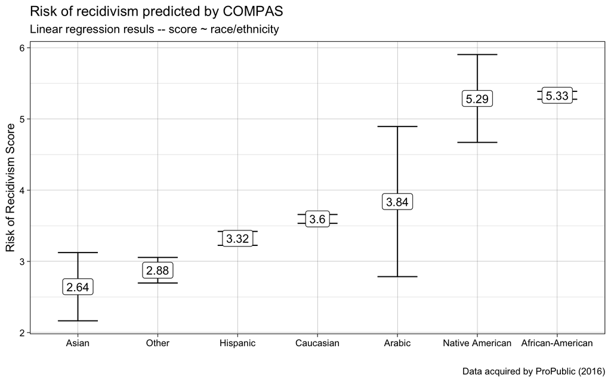

```r
effect("rec_label", model_risk_of_recidivism) %>%
  data.frame() %>%
  ggplot(aes(x = reorder(rec_label, fit),
             y = fit,
             ymin = lower,
             ymax = upper,
             label = round(fit, digits = 2))) +
  geom_errorbar(width = .5) +
  geom_label() +
  theme_linedraw() +
  labs(title = "Risk of recidivism predicted by COMPAS",
       subtitle = "Linear regression resuls -- score ~ race/ethnicity",
       caption = "Data acquired by ProPublic (2016)",
       x = "",
       y = "Risk of Recidivism Score")
```